# Capstone_Project_AIML_Group1B_NLP_Final_Submission

```
                                    Great Learning AIML Course
```

## Capstone Project : Text Classification (Chat bot) using Natural Language Processing

## Project Team

- **Aakash Sinha**
- **Aditya Kadiwal**
- **Keerthana Punithan**
- **Nitin Malhotra**
- **Rishabh Gaur**

# Overview

The Capstone project is designed to undertake a multi-faceted project that demonstrates our understanding and mastery of the key conceptual and technological aspects of Deep Learning and targets to develop an understanding of how challenging human-level problems can be approached and solved using a combination of tools and techniques.

# Project Objectives

Design a ML/DL based chatbot utility which can help the professionals to highlight the safety risk as per the incident description.

# Our Approach Summary

- **Import the data**

  We loaded the csv file as pandas dataframe to use it for all our analysis and modeling purpouses.
- **Data Cleansing**

  Cleaned the data before starting the analysis to avoid running into semantic errors.
- **Data Preprocessing**

  Initial level of data preprocessing was performed to change categorical features into encoded features. Changed DateTime features to more meaningful variables (quarter, day of week, month & year)
- **Exploratory Data Analysis**

  Detailed EDA was performed on every existing & derived feature to get insights out of the data using interactive & dynamic plots. The conclusive insights are provided below every chart for better understanding
- **NLP Preprocessing**

  The NLP preprocessing was performed on incident description feature. Removal of stopwords, lemmatization and tokenization of the text was performed to use it for our modeling purpouse
- **Data Augmentation & Feature Engineering**

  Data augmentation was performed on the complete dataset since there was an imbalance in the data for all the classes in the Critical risk field. The description text was translated into a different language and translated back to English in order to get more variety and more samples for the minority classes. Corrections were made on the misspelt words and generalization was performed for words containing dimensions, lengths, chemical names, etc.
- **Final data for Model**

**The above steps were re-performed a second time after gaining insights from the initial analysis and the final processed data was used for modeling**

**Also we only used the Incident description feature for our models because our ultimate goal is to built a chat bot which can only ask for incident description info.**

- **Modeling**
  - **ML Classifiers**

    We started modeling with ML classifiers to understand how well normal algorithm performs on the augmented data. We used multiple ML model but finalized on Lgbm, Random Forest Classifier, XGBoost Classifier as they provided best results.

**The results provided by ML classifiers were extremely good but on further research we found that these model were a little overfitted. Also in case a new word comes up in the real time testing phase then these models wont be able to perform as expected. Hence we went ahead with neural network & other sophisticated models.**

- **Neural Network**

  We built a traditional NN model to classify the text description into differnt critical risk. The model results were satisfactory but we decided to increase the model accuracy by using LSTM Model
- **LSTM Model**

  We trained and tuned a LSTM model to classify the critical risk. The model after tuning gave best results without overfitting on the existing data. This model will also work well on new description so we decided to stop the modeling with our LSTM model.
- **Model Comparison**

  We compared all models on the basis of classification report (Precision, recall, F1 score, their accuracy) & direct comparison of confusion metric of all models. We agreed to use the LSTM model as our final model after comparing all the metrics and the inherent advanteges of LSTM model.
- **Model Limitaion, Closing thoughts & References**

  Finally we discuss the current model limitation and steps for future improvement of the model as well as refer all the publication we have taken inspiration from.

## Import packages

```python
!pip install plotly==4.7.1 cufflinks word2number
```

```
     |████████████████████████████████| 11.5MB 5.1MB/s
  Found existing installation: plotly 4.4.1
    Uninstalling plotly-4.4.1:
      Successfully uninstalled plotly-4.4.1
```

```python
#!pip install plotly==4.7.1 cufflinks
import plotly
print(plotly.__version__)
import numpy as np
import pandas as pd
import matplotlib.pyplot as plt
%matplotlib inline
import seaborn as sns
import plotly.express as px
import plotly.graph_objects as go
from sklearn.impute import SimpleImputer
# Basic packages
import pandas as pd, numpy as np, matplotlib.pyplot as plt, seaborn as sns, gc
from scipy import stats; from scipy.stats import zscore, norm, randint
import matplotlib.style as style; style.use('fivethirtyeight')
# Models
from sklearn.model_selection import train_test_split, GridSearchCV, StratifiedKFold, cross_val_score, learning_curve
from wordcloud import WordCloud, STOPWORDS

# Display settings
pd.options.display.max_rows = 400
pd.options.display.max_columns = 100
pd.options.display.float_format = "{:.2f}".format

random_state = 42
np.random.seed(random_state)

# Suppress warnings
import warnings; warnings.filterwarnings('ignore')
```

```
4.7.1
```

## Import Dataset and basic info

```python
# Mounting Google Drive
from google.colab import drive
drive.mount('/content/drive')
```

```python
project_path = '/content/drive/MyDrive/GL_Capstone_Project/Notebooks/Final_report/'
data = pd.read_csv(project_path + 'Data Set - industrial_safety_and_health_database_with_accidents_description.csv')
```

```python
data.head()
```

|  | Unnamed: 0 | Data | Countries | Local | Industry Sector | Accident Level | Potential Accident Level | Genre | Employee or Third Party | Critical Risk | Description |
| --- | --- | --- | --- | --- | --- | --- | --- | --- | --- | --- | --- |
| 0 | 0 | 2016-01-01 00:00:00 | Country_01 | Local_01 | Mining | I | IV | Male | Third Party | Pressed | While removing the drill rod of the Jumbo 08 f... |
| 1 | 1 | 2016-01-02 00:00:00 | Country_02 | Local_02 | Mining | I | IV | Male | Employee | Pressurized Systems | During the activation of a sodium sulphide pum... |
| 2 | 2 | 2016-01-06 00:00:00 | Country_01 | Local_03 | Mining | I | III | Male | Third Party (Remote) | Manual Tools | In the sub-station MILPO located at level +170... |
| 3 | 3 | 2016-01-08 00:00:00 | Country_01 | Local_04 | Mining | I | I | Male | Third Party | Others | Being 9:45 am. approximately in the Nv. 1880 C... |
| 4 | 4 | 2016-01-10 00:00:00 | Country_01 | Local_04 | Mining | IV | IV | Male | Third Party | Others | Approximately at 11:45 a.m. in circumstances t... |

### Display columns

```python
data.columns
```

```
Index(['Unnamed: 0', 'Data', 'Countries', 'Local', 'Industry Sector',
       'Accident Level', 'Potential Accident Level', 'Genre',
       'Employee or Third Party', 'Critical Risk', 'Description'],
      dtype='object')
```

### Rename columns

```python
data.drop("Unnamed: 0", axis=1, inplace=True)
data.rename(columns={'Data':'Date', 'Countries':'Country', 'Genre':'Gender', 'Employee or Third Party':'Employee type'}, inplace=True)
data.head(3)
```

|  | Date | Country | Local | Industry Sector | Accident Level | Potential Accident Level | Gender | Employee type | Critical Risk | Description |
| --- | --- | --- | --- | --- | --- | --- | --- | --- | --- | --- |
| 0 | 2016-01-01 00:00:00 | Country_01 | Local_01 | Mining | I | IV | Male | Third Party | Pressed | While removing the drill rod of the Jumbo 08 f... |
| 1 | 2016-01-02 00:00:00 | Country_02 | Local_02 | Mining | I | IV | Male | Employee | Pressurized Systems | During the activation of a sodium sulphide pum... |
| 2 | 2016-01-06 00:00:00 | Country_01 | Local_03 | Mining | I | III | Male | Third Party (Remote) | Manual Tools | In the sub-station MILPO located at level +170... |

### Display datatypes

```python
data.info()
```

```
<class 'pandas.core.frame.DataFrame'>
RangeIndex: 425 entries, 0 to 424
Data columns (total 10 columns):
 #   Column                    Non-Null Count  Dtype
---  ------                    --------------  -----
 0   Date                      425 non-null    object
 1   Country                   425 non-null    object
 2   Local                     425 non-null    object
 3   Industry Sector           425 non-null    object
 4   Accident Level            425 non-null    object
 5   Potential Accident Level  425 non-null    object
 6   Gender                    425 non-null    object
 7   Employee type             425 non-null    object
 8   Critical Risk             425 non-null    object
 9   Description               425 non-null    object
dtypes: object(10)
memory usage: 33.3+ KB
```

### Display count of unique values per column

```python
columns = data[data.columns[~data.columns.isin(['Description', 'Unnamed: 0', 'Date'])]].columns.tolist()
for cols in columns:
    print(f'Unique values for {cols} is \n{data[cols].unique()}\nUnique count per label is:\n{data[cols].value_counts()}\n')
```

```
Unique values for Country is
['Country_01' 'Country_02' 'Country_03']
Unique count per label is:
Country_01    251
Country_02    130
Country_03     44
Name: Country, dtype: int64

Unique values for Local is
['Local_01' 'Local_02' 'Local_03' 'Local_04' 'Local_05' 'Local_06'
 'Local_07' 'Local_08' 'Local_10' 'Local_09' 'Local_11' 'Local_12']
Unique count per label is:
Local_03    90
Local_05    59
Local_01    57
Local_04    56
Local_06    46
Local_10    44
Local_08    27
Local_02    24
Local_07    14
Local_12     4
Local_09     2
Local_11     2
Name: Local, dtype: int64

Unique values for Industry Sector is
['Mining' 'Metals' 'Others']
Unique count per label is:
Mining    241
Metals    134
Others     50
Name: Industry Sector, dtype: int64

Unique values for Accident Level is
['I' 'IV' 'III' 'II' 'V']
Unique count per label is:
I      316
II      40
III     31
```

[output cut: 62 more lines]

```
Electrical Shock                               2
Machine Protection                             2
Projection of fragments                        2
Traffic                                        1
\nNot applicable                               1
Burn                                           1
Electrical installation                        1
Poll                                           1
Projection/Choco                               1
Individual protection equipment                1
Projection/Manual Tools                        1
Projection/Burning                             1
Confined space                                 1
Plates                                         1
Name: Critical Risk, dtype: int64
```

### Replace categorical values

```python
# replacing categorical values
replace_struc = {'Local_01': 1, 'Local_02': 2, 'Local_03': 3, 'Local_04': 4, 'Local_05': 5, 'Local_06': 6, 'Local_07': 7, 'Local_08': 8, 'Local_09': 9, 'Local_10': 10, 'Local_11': 11, 'Local_12': 12}
data['Local'] = data['Local'].map(replace_struc)
replace_struc = {'I': 0, 'II': 1, 'III': 3, 'IV': 4, 'V': 5}
data['Accident Level'] = data['Accident Level'].map(replace_struc)
replace_struc = {'I': 0, 'II': 1, 'III': 3, 'IV': 4, 'V': 5, 'VI': 6}
data['Potential Accident Level'] = data['Potential Accident Level'].map(replace_struc)
del replace_struc
```

```python
print(f'Dataset after mapping categorical values\n')
data.head()
```

```
Dataset after mapping categorical values
```

|  | Date | Country | Local | Industry Sector | Accident Level | Potential Accident Level | Gender | Employee type | Critical Risk | Description |
| --- | --- | --- | --- | --- | --- | --- | --- | --- | --- | --- |
| 0 | 2016-01-01 00:00:00 | Country_01 | 1 | Mining | 0 | 4 | Male | Third Party | Pressed | While removing the drill rod of the Jumbo 08 f... |
| 1 | 2016-01-02 00:00:00 | Country_02 | 2 | Mining | 0 | 4 | Male | Employee | Pressurized Systems | During the activation of a sodium sulphide pum... |
| 2 | 2016-01-06 00:00:00 | Country_01 | 3 | Mining | 0 | 3 | Male | Third Party (Remote) | Manual Tools | In the sub-station MILPO located at level +170... |
| 3 | 2016-01-08 00:00:00 | Country_01 | 4 | Mining | 0 | 0 | Male | Third Party | Others | Being 9:45 am. approximately in the Nv. 1880 C... |
| 4 | 2016-01-10 00:00:00 | Country_01 | 4 | Mining | 4 | 4 | Male | Third Party | Others | Approximately at 11:45 a.m. in circumstances t... |

### Check for null values

```python
data.isnull().sum()
```

```
Date                        0
Country                     0
Local                       0
Industry Sector             0
Accident Level              0
Potential Accident Level    0
Gender                      0
Employee type               0
Critical Risk               0
Description                 0
dtype: int64
```

```python
data.shape
```

```
(425, 10)
```

# Insights so Far:

- The data is fairly clean with no nulls in any columns
- Most of the features are categorical in nature.
- Critical risk is our target variable and has 33 classes

## Data Preparation

```python
#For time series analysis
data['Date'] = pd.to_datetime(data['Date'])
data['Year'] = data['Date'].apply(lambda x : x.year)
data['Month'] = data['Date'].apply(lambda x : x.month)
data['Day'] = data['Date'].apply(lambda x : x.day)
data['Weekday'] = data['Date'].apply(lambda x : x.day_name())
data.head(3)
```

|  | Date | Country | Local | Industry Sector | Accident Level | Potential Accident Level | Gender | Employee type | Critical Risk | Description | Year | Month | Day | Weekday |
| --- | --- | --- | --- | --- | --- | --- | --- | --- | --- | --- | --- | --- | --- | --- |
| 0 | 2016-01-01 | Country_01 | 1 | Mining | 0 | 4 | Male | Third Party | Pressed | While removing the drill rod of the Jumbo 08 f... | 2016 | 1 | 1 | Friday |
| 1 | 2016-01-02 | Country_02 | 2 | Mining | 0 | 4 | Male | Employee | Pressurized Systems | During the activation of a sodium sulphide pum... | 2016 | 1 | 2 | Saturday |
| 2 | 2016-01-06 | Country_01 | 3 | Mining | 0 | 3 | Male | Third Party (Remote) | Manual Tools | In the sub-station MILPO located at level +170... | 2016 | 1 | 6 | Wednesday |

```python
def month_quarter_Conversion(x):
    if x in [10, 11, 12]:
        season = 'Fourth'
    elif x in [1, 2, 3]:
        season = 'First'
    elif x in [4, 5, 6]:
        season = 'Second'
    elif x in [7, 8, 9]:
        season = 'Third'
    return season
data['Quarter'] = data['Month'].apply(month_quarter_Conversion)
data.tail(3)
```

|  | Date | Country | Local | Industry Sector | Accident Level | Potential Accident Level | Gender | Employee type | Critical Risk | Description | Year | Month | Day | Weekday | Quarter |
| --- | --- | --- | --- | --- | --- | --- | --- | --- | --- | --- | --- | --- | --- | --- | --- |
| 422 | 2017-07-05 | Country_02 | 9 | Metals | 0 | 1 | Male | Employee | Venomous Animals | During the environmental monitoring activity i... | 2017 | 7 | 5 | Wednesday | Third |
| 423 | 2017-07-06 | Country_02 | 5 | Metals | 0 | 1 | Male | Employee | Cut | The Employee performed the activity of strippi... | 2017 | 7 | 6 | Thursday | Third |
| 424 | 2017-07-09 | Country_01 | 4 | Mining | 0 | 1 | Female | Third Party | Fall prevention (same level) | At 10:00 a.m., when the assistant cleaned the ... | 2017 | 7 | 9 | Sunday | Third |

### The Date feature is converted to year, month, day, weekday and Quarter to better understand the data

## Univariate Analysis

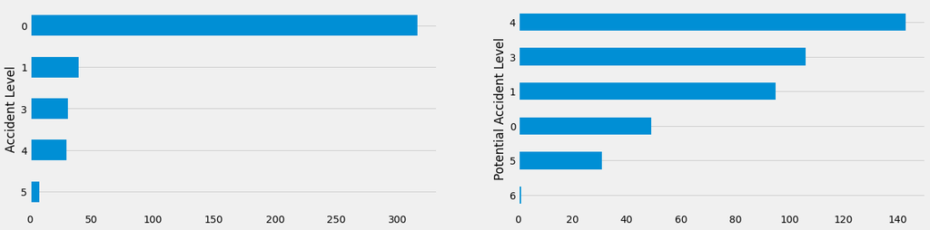

```python
fig,ax = plt.subplots(nrows=1,ncols=2,figsize=(20,5))
acc_level = "Accident Level"
data[acc_level].reset_index().groupby(acc_level).count().sort_values(by=
       "index").plot(kind="barh", legend=False,
        ax=ax[0]).grid(axis='x')

pot_acc_level = "Potential Accident Level"
data[pot_acc_level].reset_index().groupby(pot_acc_level).count().sort_values(by=
       "index").plot(kind="barh", legend=False,
        ax=ax[1]).grid(axis='x')


plt.show()
```

### Country 1 is most affected with close to 60% incidents occuring overall

- The below chart is a live interactive chart and it might not show in html & preview mode
- Please run this cell to see the plot result
- for reference we have attached the png file in the submission

```python
fig = px.pie(data, names='Country', template='seaborn')
fig.update_traces(rotation=90, pull=[0.2,0.03,0.1,0.03,0.1], textinfo="percent+label", showlegend=False)
fig.show()
```

[interactive chart not shown]

### The Mining Sector has most number of incidents with ~57% incident rate, the Metals industry has second highest incident rate with 32%

- The below chart is a live interactive chart and it might not show in html & preview mode
- Please run this cell to see the plot result
- for reference we have attached the png file in the submission

```python
fig = px.pie(data, names='Industry Sector', template='seaborn')
fig.update_traces(rotation=90, pull=[0.2,0.03,0.1,0.03,0.1], textinfo="percent+label", showlegend=False)
fig.show()
```

[interactive chart not shown]

### Direct Employees as well as on site third party contractors are most vulnerable to an incident occuring than remote workers

- The below chart is a live interactive chart and it might not show in html & preview mode
- Please run this cell to see the plot result
- for reference we have attached the png file in the submission

```python
fig = px.pie(data, names='Employee type', template='seaborn')
fig.update_traces(rotation=90, pull=[0.2,0.03,0.1,0.03,0.1], textinfo="percent+label", showlegend=False)
fig.show()
```

[interactive chart not shown]

### Risk factor analysis

- People are at risk while working near pressing machines, manual tools or chemicals. The incident rate of burn or electric shock is comparitvely less

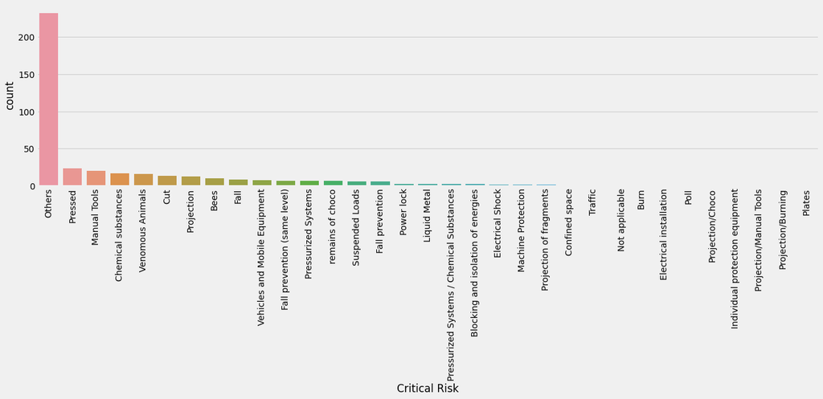

```python
plt.figure(figsize=(20,5))
descending_order = data['Critical Risk'].value_counts().sort_values(ascending=False).index
sns.countplot(x=data['Critical Risk'],order=descending_order)
plt.xticks(rotation = 'vertical')
```

### Mostly affected quarter

```python
fig = px.pie(data, names='Quarter', template='seaborn')
fig.update_traces(rotation=90, pull=[0.2,0.03,0.1,0.03,0.1], textinfo="percent+label", showlegend=False)
fig.show()
```

[interactive chart not shown]

### Mostly affected local

- Local 3 city has highest incident with 21%
- rest of the cities have similar incident and not much inference can be taken out of it.
- The below chart is a live interactive chart and it might not show in html & preview mode
- Please run this cell to see the plot result
- for reference we have attached the png file in the submission

```python
fig = px.pie(data, names='Local', template='seaborn')
fig.update_traces(rotation=90, pull=[0.2,0.03,0.1,0.03,0.1], textinfo="percent+label", showlegend=False)
fig.show()
```

[interactive chart not shown]

## Multivariate Analysis

```python
# Helper function for relation between Accident Level/Potential Accident levels
# and other labels
def target_count(df, col1):
    fig = plt.figure(figsize = (15, 7.2))
    ax = fig.add_subplot(121)
    sns.countplot(x = col1, data = df, ax = ax, orient = 'v',
                  hue = 'Accident Level').set_title(col1.capitalize() +' count plot by Accident Level',
                                                                      fontsize = 13)
    plt.legend(labels = df['Accident Level'].unique())
    plt.xticks(rotation = 90)

    ax = fig.add_subplot(122)
    sns.countplot(x = col1, data = df, ax = ax, orient = 'v',
                  hue = 'Potential Accident Level').set_title(col1.capitalize() +' count plot by Potential Accident Level',
                                                                      fontsize = 13)
    plt.legend(labels = df['Potential Accident Level'].unique())
    plt.xticks(rotation = 90)
    return plt.show()
```

### Analysis of Gender wrt Accident/ Potential Accident Level

- We see that Male accidents are higher in number than female numbers but we also need to account the data disparity as female employee count in the firms itself could be low

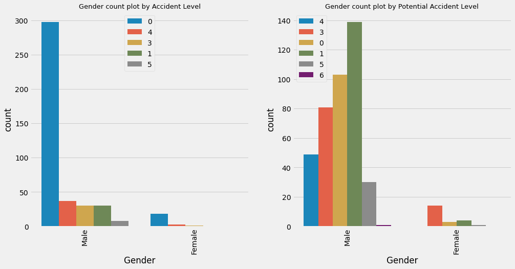

```python
target_count(data, 'Gender')
```

### Analysis of Industry Sector wrt Accident/ Potential Accident Level

- This drill down help us understand that not only mining has highest number of accident, the severity of those accidents are really high as well compared to other industries

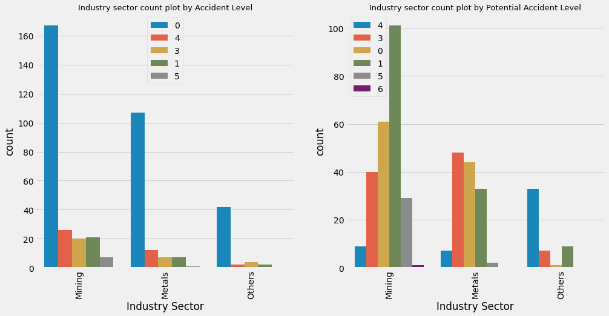

```python
target_count(data, 'Industry Sector')
```

### Analysis of Country wrt Accident/ Potential Accident Level

- Country_01 has highest level 0 to level 5 accidents
- A further drill down on the type of industry available in each country can help us assess why the accident rate is really high in this country

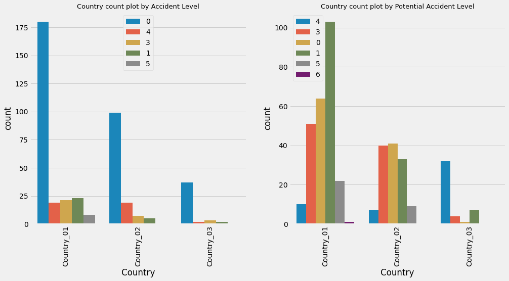

```python
target_count(data, 'Country')
```

### Analysis of Month wrt Accident/ Potential Accident Level

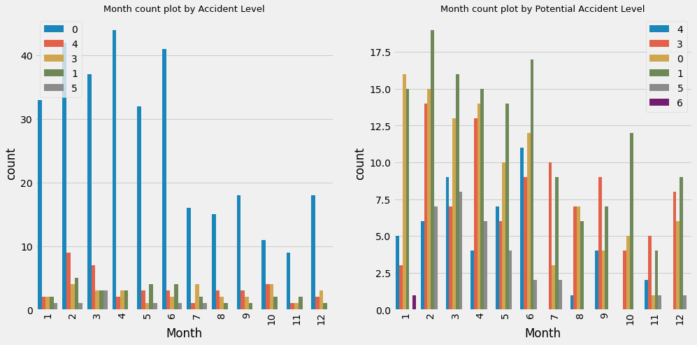

```python
target_count(data, 'Month')
```

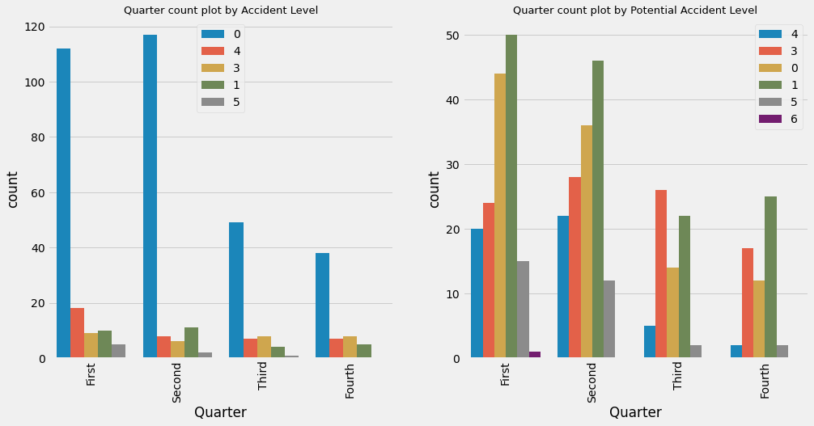

```python
target_count(data, 'Quarter')
```

### Analysis of Year wrt Accident/ Potential Accident Level

- An intersting finding here is that we see many more accident in 2016 than in 2017.
- Our hypothesis is that after multitude of incidents in 2016 some workplace reforms might have been applied to decrease the injuries

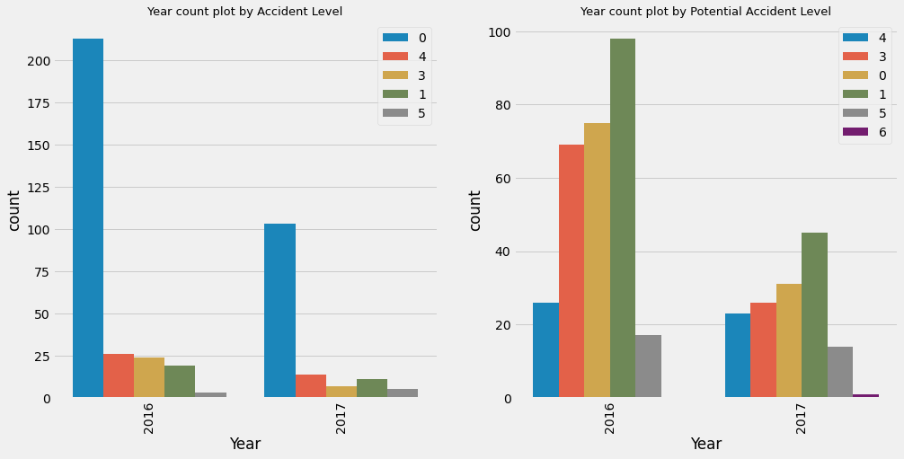

```python
target_count(data, 'Year')
```

### Analyze Country and Industry Sector

- Country 1 has highest mining industry accidents which indicates that country have high manufacturing related production

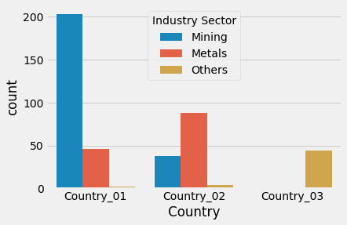

```python
sns.countplot(x="Country", data=data, hue="Industry Sector")
```

### Analyze Country and Gender

### The below 2 charts confirms our hypothesis that the count of female employees across different sector/country/ employee type are very low compared to males

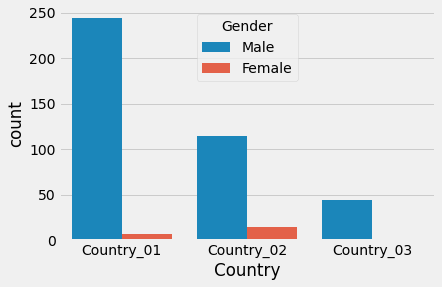

```python
sns.countplot(x="Country", data=data,hue="Gender")
```

### Analyze Employee Type and Gender

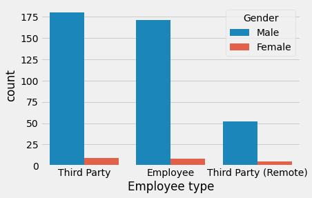

```python
sns.countplot(x="Employee type", data=data,hue="Gender")
```

### The distribution of accidents across year, sector & accident level summarizes the individual insights gained above such as Mining is the highest risk sector with accident level of 0 to 5. Also the year 2016 saw great number of accidents compared to 2017.

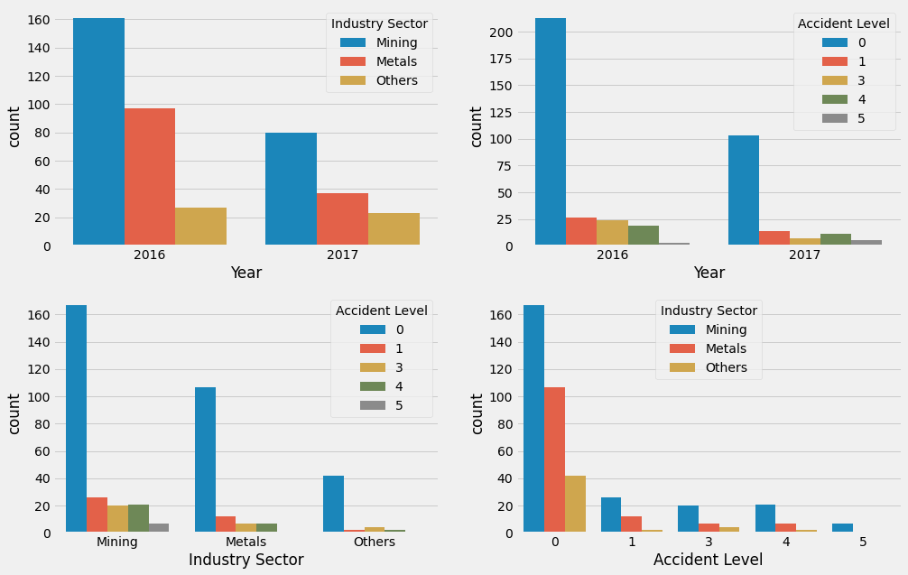

```python
fig,axs = plt.subplots(nrows=2,ncols=2,figsize=(15,10))
sns.countplot(x=data['Year'],hue='Industry Sector',data=data,ax=axs[0][0])
sns.countplot(x=data['Year'],hue='Accident Level',data=data,ax=axs[0][1])
sns.countplot(x=data['Industry Sector'],hue='Accident Level',data=data,ax=axs[1][0])
sns.countplot(x=data['Accident Level'],hue='Industry Sector',data=data,ax=axs[1][1])
```

### Analysis of activities by Critical Risk and Industry type by Months

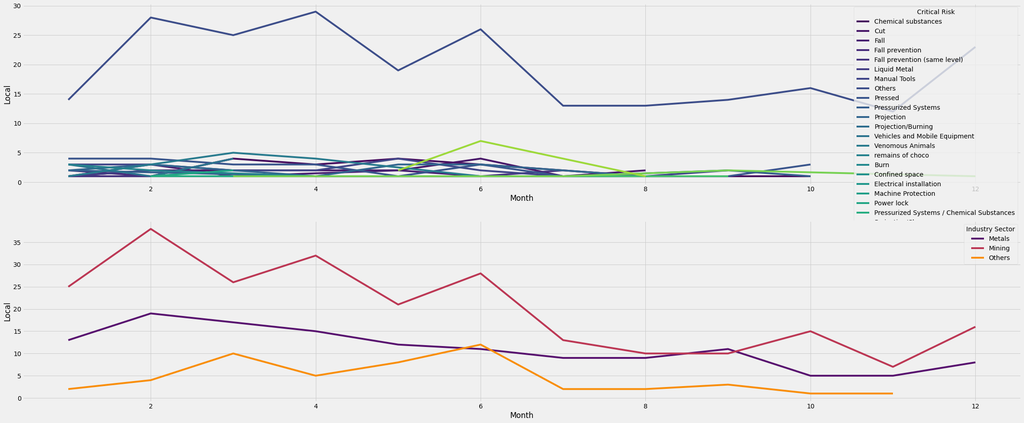

```python
def groupby_and_count(df, group_cols, agg_cols, agg):
  temp = df.groupby(group_cols).agg(dict(zip(agg_cols, agg)))
  return temp

fig, ax = plt.subplots(2,1, figsize=(35,15));
sns.lineplot(data=groupby_and_count(data, ['Month', 'Critical Risk'], ['Local'], ['count']), x="Month", y="Local", hue="Critical Risk", ax=ax[0], palette="viridis");
sns.lineplot(data=groupby_and_count(data, ['Month', 'Industry Sector'], ['Local'], ['count']), x="Month", y="Local", hue="Industry Sector", ax=ax[1], palette="inferno");
```

- Spike in bees/venomous animal bites during the Summer and Autumn
- Most incidents have occured in the first half of the years and reduced drastically in July which is when Winter starts. When cold weather causes barometric pressure to drop, methane gas can migrate more easily into the mine atmosphere, increasing the risk of an explosion. Dry winter air means drier conditions underground, making it more likely for coal dust to suspend in the mine's atmosphere and create the potential for an explosion.
- We also see a drop in mining activities starting July.
- November has the lowest number of incidents possibly because the rainy season starts then.

## Analyzing text statistics

### Number of words appearing in each description

- Most description have avg words of 50 to 100 but it goes as high as 180 words

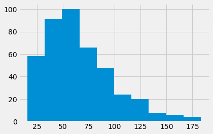

```python
data['Description'].str.split().map(lambda x: len(x)).hist()
```

### Average word length

- Most words have average length of ~5

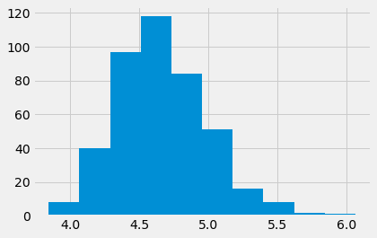

```python
data['Description'].str.split().apply(lambda x : [len(i) for i in x]). \
   map(lambda x: np.mean(x)).hist()
```

## Analyzing Word Cloud

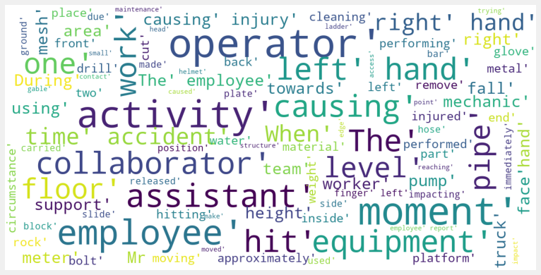

```python
from nltk.corpus import stopwords
from nltk.stem import WordNetLemmatizer,PorterStemmer
from nltk.tokenize import word_tokenize
from wordcloud import WordCloud, STOPWORDS
import nltk
nltk.download('punkt')
nltk.download('wordnet')

def plot_wordcloud(text):
    nltk.download('stopwords')
    stop=set(stopwords.words('english'))

    def _preprocess_text(text):
        corpus=[]
        stem=PorterStemmer()
        lem=WordNetLemmatizer()
        for news in text:
            words=[w for w in word_tokenize(news) if (w not in stop)]

            words=[lem.lemmatize(w) for w in words if len(w)>2]

            corpus.append(words)
        return corpus

    corpus=_preprocess_text(text)

    wordcloud = WordCloud(
        background_color='white',
        stopwords=set(STOPWORDS),
        max_words=100,
        max_font_size=30,
        scale=3,
        random_state=1)

    wordcloud=wordcloud.generate(str(corpus))

    fig = plt.figure(1, figsize=(12, 12))
    plt.axis('off')

    plt.imshow(wordcloud)
    plt.show()

plot_wordcloud(data['Description'])
```

# Preprocessing for Model

```python
import random

import nltk
from nltk import ngrams
from nltk.stem import WordNetLemmatizer, SnowballStemmer
from nltk.stem.porter import *
from nltk.corpus import stopwords
from nltk.tokenize import word_tokenize
from sklearn.feature_extraction.text import CountVectorizer
from sklearn.model_selection import train_test_split
from sklearn.feature_extraction.text import TfidfTransformer
from sklearn.metrics import classification_report
from sklearn.metrics import accuracy_score

import lightgbm as lgb
from xgboost import XGBClassifier
from sklearn.ensemble import RandomForestClassifier

import tensorflow as tf
from tensorflow.keras import regularizers, optimizers
from tensorflow.keras.models import Sequential
from tensorflow.keras.layers import InputLayer, Activation, Dropout, Flatten, Dense, Conv2D, MaxPooling2D, GlobalMaxPool2D, BatchNormalization, MaxPool2D, Conv1D, MaxPooling1D, GlobalMaxPooling1D, Embedding
from tensorflow.keras.optimizers import Adam, SGD
from numpy import expand_dims
from keras.preprocessing.text import Tokenizer
from tensorflow.keras.callbacks import LearningRateScheduler, ModelCheckpoint


from collections import Counter
from word2number import w2n

random.seed(42)
%matplotlib inline

# Charting options
sns.set(context= "notebook", color_codes=True)
plt.style.use('bmh')
# Set notebook mode to work in offline
# pyo.init_notebook_mode()

# Ignore the warnings
import warnings
warnings.filterwarnings("ignore")

nltk.download('wordnet')
nltk.download('stopwords')
nltk.download('punkt')

roman_numerals = {'I': 1, 'II': 2, 'III': 3, 'IV': 4, 'V': 5, 'VI': 6, 'VII': 7, 'VIII': 8, 'IX': 9, 'X': 10}
```

```python
df = pd.read_csv(project_path + 'Data Set - industrial_safety_and_health_database_with_accidents_description.csv')
df.columns = [i.lower().replace(' ', '_') for i in df.columns]
df = df[['critical_risk', 'description']]
df
```

|  | critical_risk | description |
| --- | --- | --- |
| 0 | Pressed | While removing the drill rod of the Jumbo 08 f... |
| 1 | Pressurized Systems | During the activation of a sodium sulphide pum... |
| 2 | Manual Tools | In the sub-station MILPO located at level +170... |
| 3 | Others | Being 9:45 am. approximately in the Nv. 1880 C... |
| 4 | Others | Approximately at 11:45 a.m. in circumstances t... |
| ... | ... | ... |
| 420 | Others | Being approximately 5:00 a.m. approximately, w... |
| 421 | Others | The collaborator moved from the infrastructure... |
| 422 | Venomous Animals | During the environmental monitoring activity i... |
| 423 | Cut | The Employee performed the activity of strippi... |
| 424 | Fall prevention (same level) | At 10:00 a.m., when the assistant cleaned the ... |

425 rows × 2 columns

## Merge topics based on the similarity of words/sentences in the description column

```
1. Bees and Venomous Animals
2. Electric installation and Electric Shock
3. Fall and Fall prevention and Fall prevention (same level)
4. Chemical substances and Liquid Metal and Pressurized Systems / Chemical Substances and Pressurized Systems
5. Machine Protection and Cut and Plates and Poll
6. Projection and Projection of fragments and Projection/Burning and Projection/Choco and Projection/Manual Tools and remains of choco
7. Vehicles and Mobile Equipment and Traffic
```

```python
df['critical_risk'] = df['critical_risk'].replace({'\nNot applicable' : 'NA'}) # Convert \nNot applicable to NA
df.loc[df['critical_risk'].isin(['Bees', 'Venomous Animals']), 'critical_risk'] = 'Bees/Venomous Animals'
df.loc[df['critical_risk'].isin(['Electrical installation', 'Electrical Shock']), 'critical_risk'] = 'Hazards during Electrical installations'
df.loc[df['critical_risk'].isin(['Fall', 'Fall prevention', 'Fall prevention (same level)']), 'critical_risk'] = 'Fall'
df.loc[df['critical_risk'].isin(['Burn', 'Confined space', 'Chemical substances', 'Liquid Metal', 'Pressurized Systems / Chemical Substances', 'Pressurized Systems']), 'critical_risk'] = 'Pressurized Systems/ Chemical Substances'
df.loc[df['critical_risk'].isin(['Machine Protection', 'Cut', 'Plates', 'Poll']), 'critical_risk'] = 'Injuries/Cuts'
df.loc[df['critical_risk'].isin(['Projection', 'Projection of fragments', 'Projection/Burning', 'Projection/Choco', 'Projection/Manual Tools', 'remains of choco', 'Individual protection equipment']), 'critical_risk'] = 'Projections of fragments'
df.loc[df['critical_risk'].isin(['Vehicles and Mobile Equipment', 'Traffic']), 'critical_risk'] = 'Vehicles and Mobile Equipment'
```

## Data augmentation/Oversampling

Since we have a huge imbalance in the classes in our dataset, we will try to generate more samples using translations.

```python
df_translated = pd.read_excel(project_path + 'accidents_translated.xlsx')
df_translated.columns = [i.lower().replace(' ', '_') for i in df_translated.columns]
df_translated = df_translated[['portuguese_translated', 'italian_translated', 'spanish_translated', 'critical_risk', 'description']]

df_translated['critical_risk'] = df_translated['critical_risk'].replace({'\nNot applicable' : 'NA'}) # Convert \nNot applicable to NA

df_translated.loc[df_translated['critical_risk'].isin(['Bees', 'Venomous Animals']), 'critical_risk'] = 'Bees/Venomous Animals'
df_translated.loc[df_translated['critical_risk'].isin(['Electrical installation', 'Electrical Shock']), 'critical_risk'] = 'Hazards during Electrical installations'
df_translated.loc[df_translated['critical_risk'].isin(['Fall', 'Fall prevention', 'Fall prevention (same level)']), 'critical_risk'] = 'Fall'
df_translated.loc[df_translated['critical_risk'].isin(['Burn', 'Confined space', 'Chemical substances', 'Liquid Metal', 'Pressurized Systems / Chemical Substances', 'Pressurized Systems']), 'critical_risk'] = 'Pressurized Systems/ Chemical Substances'
df_translated.loc[df_translated['critical_risk'].isin(['Machine Protection', 'Cut', 'Plates', 'Poll']), 'critical_risk'] = 'Injuries/Cuts'
df_translated.loc[df_translated['critical_risk'].isin(['Projection', 'Projection of fragments', 'Projection/Burning', 'Projection/Choco', 'Projection/Manual Tools', 'remains of choco', 'Individual protection equipment']), 'critical_risk'] = 'Projections of fragments'
df_translated.loc[df_translated['critical_risk'].isin(['Vehicles and Mobile Equipment', 'Traffic']), 'critical_risk'] = 'Vehicles and Mobile Equipment'

critical_counts = df['critical_risk'].value_counts().reset_index()
critical_counts_max = critical_counts['critical_risk'].max()

df_translated_full = pd.DataFrame()

# A helper function that selects one of the three translated texts at random
def translate_sentence(sent1, sent2, sent3):
  sentences = [sent1, sent2, sent3]
  this_sent = random.choice(sentences)
  return this_sent

for risk in critical_counts.to_dict('records'):
  new_df = df_translated[df_translated['critical_risk'] == risk['index']].sample(critical_counts_max - risk['critical_risk'], replace=True, random_state=42)
  new_df['description'] = new_df.apply(lambda x: translate_sentence(x.portuguese_translated, x.spanish_translated, x.italian_translated), axis=1)
  df_translated_full = df_translated_full.append(new_df)

df_translated_full.drop(columns=['portuguese_translated', 'italian_translated', 'spanish_translated'], inplace=True)
df = pd.concat([df, df_translated_full], axis=0)
df = df.reset_index().drop(columns=['index'])
```

```python
df_translated.iloc[420]
```

```
portuguese_translated    During the execution of the task of soil sampl...
italian_translated       While performing the soil sampling task at the...
spanish_translated       During the execution of the task of soil sampl...
critical_risk                                        Bees/Venomous Animals
description              During the execution of the soil sampling task...
Name: 420, dtype: object
```

### Steps involved in oversampling

```
1. Create a copy of the original dataset.
2. Translate the description to a few different languages like Portuguese, Italian and Spanish.
3. Translate the translated text back to English
```

### Why was this done?

```
1. Since there is an imbalance in the data, we need more data sample for the minority classes so that our models are not biased towards the other majority classes.
2. This double stage translation would give us a bit more variety of the same data. Doing this would change the structure of the sentence but not the meaning.
```

### Example:

##### Original:

```
During the execution of the soil sampling task at the Potions area, around 1:15 pm, Luis - WCA, was opening with a machete
and was bitten by a wasp on the back of his right hand, the same was using at the time of the incident all the EPIs needed
for activity. The employee was evaluated by the technician who found it to be a mild and localized swelling wound. The
employee reported that he did not feel any pain and that he could continue the activity.
```

##### 1. English -> Portuguese -> English

```
During the execution of the task of soil sampling in the area of Poções, around 13h15, Luis - WCA, was opening with a machete
and was bitten by a wasp on the back of his right hand, the same was wearing at the time of the incident all the PPE
required for the activity. The employee was evaluated by the technician who found that it was a mild, localized swelling
wound. The employee reported that he felt no pain and could continue the activity.
```

##### 2. English -> Italian -> English

```
While performing the soil sampling task at the potions area, around 1:15 pm, Luis - WCA, was opening with a machete
and was bitten by a wasp on the back of his right hand, the same was using at the time of the incident all the EPI's
needed for the task. The employee was evaluated by the technician who found a minor, localized swelling injury. The
employee reported feeling no pain and was able to continue the activity.
```

##### 3. English -> Spanish -> English

```
During the execution of the task of soil sampling in the Potions area, at around 13:15 hours, Luis - WCA, was opening with a machete
and was stung by a wasp on the back of his right hand, he was using at the time of the incident all the necessary PPE
for the activity. The employee was assessed by the technician who determined that it was a minor injury with
localised swelling. The employee reported that he did not feel any pain and was able to continue the activity.
```

## Data correction/generalisation

1. A few words in the corpus were spelled incorrectly which were corrected manually.
2. Any chemical names or chemical symbols appearing will be converted to a string 'chemical'. A list of all chemical compounds and elements was obtained using Wikipedia.

```python
df_conversion = pd.read_excel(project_path + "conversions.xlsx", sheet_name=0)
df_conversion = df_conversion[["ori", "convert"]]
df_conversion = df_conversion[~df_conversion.convert.isna()] # Filter rows where not NA
df_conversion.head(10)
```

|  | ori | convert |
| --- | --- | --- |
| 0 | z*** | z_num |
| 1 | units | unit |
| 2 | unevenness | uneven |
| 3 | traumatism | trauma |
| 4 | traumatic | trauma |
| 5 | transfe | transfer |
| 6 | tranfer | transfer |
| 7 | transfer | transfer |
| 8 | tirfor | tirford |
| 9 | magnetometers | magnetometric |

Read excel file for word correction/conversion

```python
df_chem = pd.read_excel(project_path + "conversions.xlsx", sheet_name=1)
df_chem = df_chem[["chemical_formula", "synonyms"]]
df_chem = df_chem[~df_chem.synonyms.isna()] # Filter rows where not NA
df_chem
```

|  | chemical_formula | synonyms |
| --- | --- | --- |
| 0 | Ac2O3 | actinium oxide |
| 1 | AgBF4 | Silver tetrafluoroborate |
| 2 | AgBr | silver bromide |
| 3 | AgBrO | silver hypobromite |
| 4 | AgBrO2 | silver bromite |
| ... | ... | ... |
| 2563 | Fl | Flerovium |
| 2564 | Mc | Moscovium |
| 2565 | Lv | Livermorium |
| 2566 | Ts | Tennessine |
| 2567 | Og | Oganesson |

2568 rows × 2 columns

# Data Preprocessing

```python
stop_word_list = list(set(stopwords.words('english'))) # Load standard stop words
stopword_pattern = re.compile(r'\b(' + r'|'.join(stop_word_list) + r')\b\s*') # Compile regex to remove stopwords
df['desc'] = df['description'].str.lower().str.replace('[^a-zA-Z0-9 ]', '', regex=True).str.replace('mx', 'm x ').str.replace(stopword_pattern, ' ', regex=True) # Replace 10cmx20cm to 10cm x 20cm
df['desc'] = df['desc'].str.split(' ')

# Convert words to numbers
def convert_numbers(x):
  new_x = []
  for word in x:
    try:
      word = w2n.word_to_num(word.lower())
    except Exception as e:
      word = word.lower()
    if len(str(word)) > 0: # If the length of the word is zero, then don't return
      new_x.append(str(word))
  return ' '.join(new_x)

df['desc'] = df['desc'].apply(convert_numbers)

# High frequency occuring bigram removal
bigram_stop_pattern = "(i?)(left hand|left foot|left leg|left arm|right hand|right leg|right foot|right arm|time accident|causing the injury|caused the injury|caused injury|causing injury)+"
df["desc"] = df["desc"].str.replace(bigram_stop_pattern, '', regex=True)

# Convert any dimensions like 10cm x 20cm x 30cm to xdimension
dimension_pattern = re.compile(r"(i?)((([\d.]+)\s{0,}(cm|m)\s{0,})+(\s{0,}[x|X]\s{0,}\b|\b))+")
df["desc"] = df["desc"].str.replace(dimension_pattern, ' xdimension ', regex=True)

# Convert weights to xweight
weight_pattern = re.compile(r"(?i)([\d.]+)\s{0,}(lb(s\b|\b)|pound(s\b|\b)|ton(s\b|\b)|kilogram(s\b|\b)|gram(s\b|\b)|ounce(s\b|\b)|oz(s\b|\b)|g(s\b|\b)|gr(s\b|\b)|kg(s\b|\b)|tn(s\b|\b))")
df["desc"] = df["desc"].str.replace(weight_pattern, ' xweight ', regex=True)

# Convert lenghts/heights to xlength
lenght_pattern = re.compile(r"(?i)([\d.]+)\s{0,}(millimeter(s\b|\b)|centimeter(s\b|\b)|meter(s\b|\b)|kilometer(s\b|\b)|mm(s\b|\b)|cm(s\b|\b)|m(s\b|\b)|km(s\b|\b)|mt(s\b|\b)|inch|inches|yard(s\b|\b))")
df["desc"] = df["desc"].str.replace(lenght_pattern, ' xlength ', regex=True)

df['desc'] = df['desc'].str.split(' ')
```

### Preprocessing before lemmatization

1. Any words that represent a number like **three** or **one** are converted to their numerical form.
2. Bigrams that appear very frequently like **left hand**, **right foot**, etc. are removed.
3. Any dimensions like **10cm x 20cm x 30cm** or **3m x 6m** are converted to a string **xdimension**
4. Any words representing weights like **30gm** or **152lbs** are converted to a string **xweight**
5. Any words representing lengths or depths like **5 kilometers** or **1 inch** are converted to a string **xlength**

```python
chemical_names = df_chem['synonyms'].str.lower().to_list() # Get a list of all chemical names
chemical_symbols = df_chem['chemical_formula'].dropna().astype('str').str.lower().to_list() # Get a list of all chemical symbols
```

## Final data preprocessing

1. Convert to lowercase
2. Correction/conversion of words
3. Convert chemical names/chemical symbols to 'chemical'
4. Lemmatize the words
5. Remove pure numeric words

```python
df_conversion_dict = {i['ori']:i['convert'] for i in df_conversion.to_dict('records')}

lemma = WordNetLemmatizer()
def convert_words(word): # Word corrections in case of typing mistakes
  if word in df_conversion_dict:
    return df_conversion_dict[word]
  else:
    return word

def convert_chemicals(word): # Convert chemical names/symbols to 'chemical'
  if word in chemical_names or word in chemical_symbols:
    return 'chemical'
  else:
    return word

def stop_word_removal(word): # Remove any stopwords
  if word not in stop_word_list:
    return word
  else:
    return ''

def data_preprocessing(word): # Chain all functions together to perform the data preprocessing
  word = word.lower()
  word = convert_words(word)
  word = convert_chemicals(word)
  word = lemma.lemmatize(word, 'v')
  if word.isnumeric():
    return ''
  return word
```

```python
df['desc'] = df['desc'].apply(lambda x: [data_preprocessing(i) for i in x if len(data_preprocessing(i)) > 0])
df['len'] = df['desc'].apply(len)
```

```python
words_all = dict(Counter([data_preprocessing(word) for word in sum(df['desc'].to_list(), []) if len(word) > 0]))
ngram_words = dict(Counter(list(ngrams([word.lower() for word in sum(df['desc'].to_list(), []) if len(word) > 0], 2)))) # Get a list of all bigrams and the count of their frequency
```

```python
ngram_words_sorted = [(k,v) for k,v in ngram_words.items() if v >= 160]
ngram_words_sorted.sort(key = lambda x: x[1], reverse=True)
```

Create a list of bigrams and analyse the most occuring bigrams in the corpus

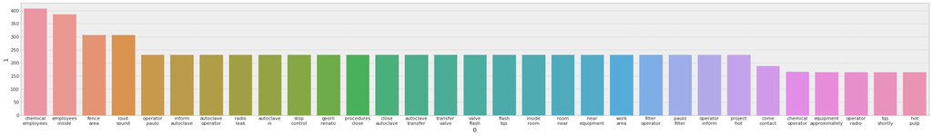

```python
plt.figure(figsize=(35,5))
temp = pd.DataFrame(ngram_words_sorted)
temp[0] = temp[0].str.join('\n')
sns.barplot(data=temp, x=0, y=1);
```

```python
df['desc_split'] = df['desc']
df['desc'] = df['desc'].str.join(' ')
```

## Data Vectorization:

### Count Vectorization

Count Vectorization will create a matrix consisting of term/token counts by the number of rows.

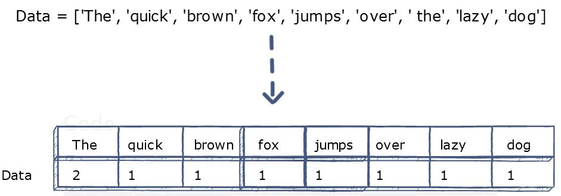

```python
vectorizer = CountVectorizer(ngram_range=(1,1))
df_vectorized = vectorizer.fit_transform(df['desc'])
```

- It is an information retrieval technique that weights a term's frequency **TF** and its inverse document frequency **IDF**.
- Based on the occurance of a term in a document, it will have its own TF and IDF score.

  ```
  TF(t) = (Number of times term t appears in a document) / (Total number of terms in the document)
  IDF(t) = log_e(Total number of documents / Number of documents with term t in it).
  ```

- A product of these two scores gives us the weight of the term in the document and the higher the score is, the rarer the term is in the given document and vice-versa.

$tfidf( t, d, D ) = tf( t, d ) \times idf( t, D )$

```python
tf_vec = df_vectorized.toarray()
normalized_tf = tf_vec[2] / np.sqrt(np.sum(tf_vec[2]**2))
tfidf = TfidfTransformer(use_idf=False, norm='l2', smooth_idf=False)
tf_normalized = tfidf.fit_transform(tf_vec)
```

```python
df_countVec = pd.concat([df[['critical_risk']], pd.DataFrame(df_vectorized.toarray())], axis=1) # Concatenate the critical risk with CountVectorizer matrix
df_tfidf = pd.concat([df[['critical_risk']], pd.DataFrame(tf_normalized.toarray())], axis=1) # Concatenate the critical risk with Tf-Idf matrix
```

```python
X_countVec = df_countVec.drop(columns=['critical_risk'])
y_countVec = df_countVec[['critical_risk']]

X_tfidf = df_tfidf.drop(columns=['critical_risk'])
y_tfidf = df_tfidf[['critical_risk']]
```

```python
y_conv_countVec = pd.get_dummies(y_countVec['critical_risk'])
y_conv_tfidf = pd.get_dummies(y_tfidf['critical_risk'])
```

Split the count vectorized and Tf-Idf matrix into their respective training and testing datasets

```python
X_countVec_train, X_countVec_test, y_countVec_train, y_countVec_test = train_test_split(X_countVec, y_countVec, test_size=0.3, random_state=42)
X_tfidf_train, X_tfidf_test, y_tfidf_train, y_tfidf_test = train_test_split(X_tfidf, y_tfidf, test_size=0.3, random_state=42)
```

# Train ML Classifiers

```python
encoded_cols = {ix:i for ix,i in enumerate(vectorizer.get_feature_names())}

y_test_conv = pd.get_dummies(y_countVec_test)
classes = y_test_conv.columns
classes = [i.replace('critical_risk_', '') for i in classes]
label_mapping = {i:ix for ix, i in enumerate(classes)}

def train_ml_classifier(df, clf, X_train, y_train, X_test, y_test, overfit_check=False, model_name=''):
  clf.fit(X_train, y_train)

  y_pred=clf.predict(X_train)
  print(f"Train score: {round(accuracy_score(y_train, y_pred) * 100)} %")
  if overfit_check:
    print(clf)
    print("Training Classification report: \n{}\n".format(
      classification_report(y_train, y_pred)))

  y_pred=clf.predict(X_test)
  print("Testing Classification report: \n{}\n".format(
    classification_report(y_test, y_pred)))


  cols = list(df.columns)
  cols.remove('critical_risk')
  cols = [encoded_cols[col] if col in encoded_cols else col[:8] + '\n' + col[8:] for col in cols]

  try:
    clf.feature_importances_
    plt.figure(figsize=(35,5));
    sns.barplot(data=pd.DataFrame(dict(zip(cols,clf.feature_importances_)), index=[1]).T.reset_index().sort_values(1, ascending=False).head(30), x="index", y=1, palette='cividis');
  except:
    pass

  act_pred_df = pd.DataFrame({'Actual' : y_test['critical_risk'].to_numpy(), 'Predicted' : y_pred})
  act_pred_df['Model'] = model_name
  act_pred_df['Actual'] = act_pred_df['Actual'].replace(label_mapping)
  act_pred_df['Predicted'] = act_pred_df['Predicted'].replace(label_mapping)

  return clf, y_pred, act_pred_df
```

## LightGBMClassifier

```
Train score: 97 %
Testing Classification report:
                                          precision    recall  f1-score   support

                   Bees/Venomous Animals       0.97      1.00      0.99        67
      Blocking and isolation of energies       1.00      1.00      1.00        63
                                    Fall       0.83      1.00      0.91        62
 Hazards during Electrical installations       1.00      1.00      1.00        71
                           Injuries/Cuts       0.92      1.00      0.96        67
                            Manual Tools       0.89      0.94      0.92        69
                                      NA       1.00      1.00      1.00        69
                                  Others       0.97      0.48      0.64        79
                              Power lock       1.00      1.00      1.00        72
                                 Pressed       0.94      0.97      0.96        79
Pressurized Systems/ Chemical Substances       0.92      0.98      0.95        83
                Projections of fragments       0.87      0.95      0.91        64
                         Suspended Loads       1.00      1.00      1.00        59
           Vehicles and Mobile Equipment       0.99      1.00      0.99        71

                                accuracy                           0.95       975
                               macro avg       0.95      0.95      0.94       975
                            weighted avg       0.95      0.95      0.94       975
```

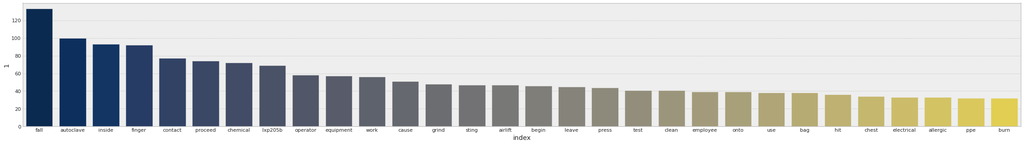

```python
lgbm_countVec = lgb.LGBMClassifier(learning_rate=0.1, max_depth=2, max_bin=3, num_leaves=5, num_iterations=100,objective='multiclass',
                          boosting_type='gbdt')
lgbm_countVec, lgbm_countVec_pred, lgbm_countVec_act_pred = train_ml_classifier(df_countVec, lgbm_countVec, X_countVec_train, y_countVec_train, X_countVec_test, y_countVec_test, model_name='LightGBM CountVectorized')
```

## The LGBM model trained on count vectorizer data performs with below mentioned metrics

- accuracy: 95%
- average precision :95%
- recall : 95%
- F1 score : 94%

```
Train score: 99 %
Testing Classification report:
                                          precision    recall  f1-score   support

                   Bees/Venomous Animals       0.97      1.00      0.99        67
      Blocking and isolation of energies       1.00      1.00      1.00        63
                                    Fall       0.85      1.00      0.92        62
 Hazards during Electrical installations       1.00      1.00      1.00        71
                           Injuries/Cuts       0.92      1.00      0.96        67
                            Manual Tools       0.93      0.97      0.95        69
                                      NA       1.00      1.00      1.00        69
                                  Others       1.00      0.61      0.76        79
                              Power lock       1.00      1.00      1.00        72
                                 Pressed       0.94      0.97      0.96        79
Pressurized Systems/ Chemical Substances       0.95      0.98      0.96        83
                Projections of fragments       0.94      0.98      0.96        64
                         Suspended Loads       1.00      1.00      1.00        59
           Vehicles and Mobile Equipment       0.99      1.00      0.99        71

                                accuracy                           0.96       975
                               macro avg       0.96      0.97      0.96       975
                            weighted avg       0.96      0.96      0.96       975
```

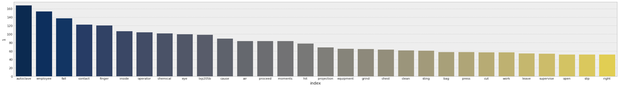

```python
lgbm_tfidf = lgb.LGBMClassifier(learning_rate=0.1, max_depth=3, max_bin=3, num_leaves=5, num_iterations=100,objective='multiclass',
                          boosting_type='gbdt')
lgbm_tfidf, lgbm_tfidf_pred, lgbm_tfidf_act_pred = train_ml_classifier(df_countVec, lgbm_tfidf, X_tfidf_train, y_tfidf_train, X_tfidf_test, y_tfidf_test, model_name='LightGBM Tf-Idf')
```

## RandomForest Classifier

```
Train score: 100 %
Testing Classification report:
                                          precision    recall  f1-score   support

                   Bees/Venomous Animals       0.96      1.00      0.98        67
      Blocking and isolation of energies       1.00      1.00      1.00        63
                                    Fall       0.89      1.00      0.94        62
 Hazards during Electrical installations       1.00      1.00      1.00        71
                           Injuries/Cuts       0.99      1.00      0.99        67
                            Manual Tools       0.99      1.00      0.99        69
                                      NA       1.00      1.00      1.00        69
                                  Others       1.00      0.76      0.86        79
                              Power lock       1.00      1.00      1.00        72
                                 Pressed       0.96      1.00      0.98        79
Pressurized Systems/ Chemical Substances       0.97      1.00      0.98        83
                Projections of fragments       1.00      1.00      1.00        64
                         Suspended Loads       1.00      1.00      1.00        59
           Vehicles and Mobile Equipment       1.00      1.00      1.00        71

                                accuracy                           0.98       975
                               macro avg       0.98      0.98      0.98       975
                            weighted avg       0.98      0.98      0.98       975
```

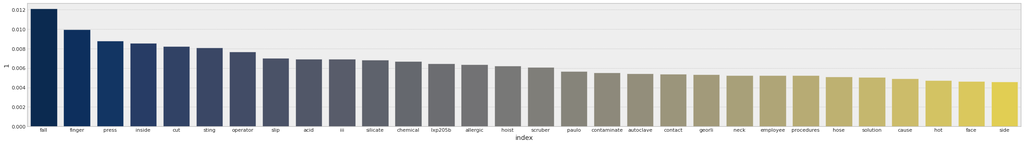

```python
rfc_countVec = RandomForestClassifier()
rfc_countVec, rfc_countVec_pred, rfc_countVec_act_pred = train_ml_classifier(df_countVec, rfc_countVec, X_countVec_train, y_countVec_train, X_countVec_test, y_countVec_test, model_name='RandomForest CountVectorized')
```

## The RF model trained on count vectorizer data performs with below mentioned metrics

- accuracy: 98%
- average precision :98%
- recall : 98%
- F1 score : 98%

```
Train score: 100 %
Testing Classification report:
                                          precision    recall  f1-score   support

                   Bees/Venomous Animals       0.96      1.00      0.98        67
      Blocking and isolation of energies       1.00      1.00      1.00        63
                                    Fall       0.90      1.00      0.95        62
 Hazards during Electrical installations       1.00      1.00      1.00        71
                           Injuries/Cuts       1.00      1.00      1.00        67
                            Manual Tools       0.99      1.00      0.99        69
                                      NA       1.00      1.00      1.00        69
                                  Others       1.00      0.78      0.88        79
                              Power lock       1.00      1.00      1.00        72
                                 Pressed       0.95      1.00      0.98        79
Pressurized Systems/ Chemical Substances       0.98      1.00      0.99        83
                Projections of fragments       1.00      1.00      1.00        64
                         Suspended Loads       1.00      1.00      1.00        59
           Vehicles and Mobile Equipment       1.00      1.00      1.00        71

                                accuracy                           0.98       975
                               macro avg       0.98      0.98      0.98       975
                            weighted avg       0.98      0.98      0.98       975
```

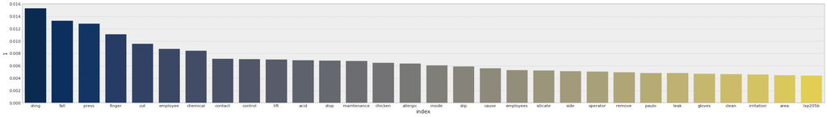

```python
rfc_tfidf = RandomForestClassifier()
rfc_tfidf, rfc_tfidf_pred, rfc_tfidf_act_pred = train_ml_classifier(df_countVec, rfc_tfidf, X_tfidf_train, y_tfidf_train, X_tfidf_test, y_tfidf_test, model_name='RandomForest Tf-Idf')
```

## XGBOOST Classifier

```
Train score: 99 %
Testing Classification report:
                                          precision    recall  f1-score   support

                   Bees/Venomous Animals       0.97      1.00      0.99        67
      Blocking and isolation of energies       1.00      1.00      1.00        63
                                    Fall       0.87      1.00      0.93        62
 Hazards during Electrical installations       1.00      1.00      1.00        71
                           Injuries/Cuts       0.96      1.00      0.98        67
                            Manual Tools       0.92      0.99      0.95        69
                                      NA       1.00      1.00      1.00        69
                                  Others       0.98      0.61      0.75        79
                              Power lock       1.00      1.00      1.00        72
                                 Pressed       0.93      0.97      0.95        79
Pressurized Systems/ Chemical Substances       0.94      0.98      0.96        83
                Projections of fragments       0.93      0.98      0.95        64
                         Suspended Loads       1.00      1.00      1.00        59
           Vehicles and Mobile Equipment       1.00      1.00      1.00        71

                                accuracy                           0.96       975
                               macro avg       0.96      0.97      0.96       975
                            weighted avg       0.96      0.96      0.96       975
```

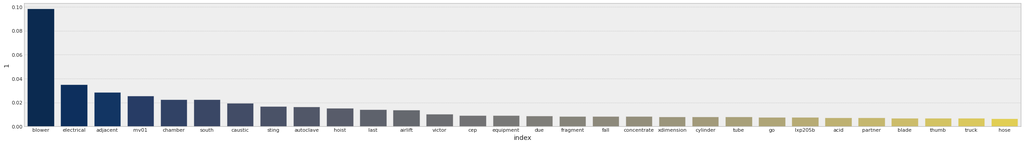

```python
xgb_countVec = XGBClassifier()
xgb_countVec, xgb_countVec_pred, xgb_countVec_act_pred = train_ml_classifier(df_countVec, xgb_countVec, X_countVec_train, y_countVec_train, X_countVec_test, y_countVec_test, model_name='XGBoost CountVectorized')
```

```
Train score: 99 %
Testing Classification report:
                                          precision    recall  f1-score   support

                   Bees/Venomous Animals       0.96      1.00      0.98        67
      Blocking and isolation of energies       1.00      1.00      1.00        63
                                    Fall       0.87      1.00      0.93        62
 Hazards during Electrical installations       1.00      1.00      1.00        71
                           Injuries/Cuts       0.97      1.00      0.99        67
                            Manual Tools       0.94      0.99      0.96        69
                                      NA       1.00      1.00      1.00        69
                                  Others       0.98      0.65      0.78        79
                              Power lock       0.99      1.00      0.99        72
                                 Pressed       0.93      0.97      0.95        79
Pressurized Systems/ Chemical Substances       0.96      0.99      0.98        83
                Projections of fragments       0.96      1.00      0.98        64
                         Suspended Loads       1.00      1.00      1.00        59
           Vehicles and Mobile Equipment       1.00      1.00      1.00        71

                                accuracy                           0.97       975
                               macro avg       0.97      0.97      0.97       975
                            weighted avg       0.97      0.97      0.96       975
```

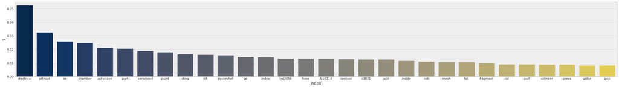

```python
xgb_tfidf = XGBClassifier()
xgb_tfidf, xgb_tfidf_pred, xgb_tfidf_act_pred = train_ml_classifier(df_countVec, xgb_tfidf, X_tfidf_train, y_tfidf_train, X_tfidf_test, y_tfidf_test, model_name='XGboost Tf-Idf')
```

## The XGB model trained on TF-IDF data performs with below mentioned metrics

- accuracy: 97%
- average precision :97%
- recall : 97%
- F1 score : 97%

# Neural network

```python
def build_nn_model(model_layers, optimizer, loss_type):
    model = Sequential()
    for layer in model_layers:
        model.add(layer)
    model.compile(optimizer=optimizer, loss=loss_type, metrics=['accuracy'])
    return model

def lr_scheduler(epoch, lr):
    decay_rate = 0.1
    decay_step = 90
    if epoch % decay_step == 0 and epoch:
        return lr * decay_rate
    return lr
```

```python
def train_model(nn_model, target_col, epochs, X, y, lr, momentum):
    num_classes = int(y.nunique())

    y_conv = pd.get_dummies(y[target_col])
    X_train, X_test, y_train, y_test = train_test_split(X, y_conv, test_size=0.3, train_size=0.7, random_state=42)

    print(nn_model.summary())

    model_checkpoint = ModelCheckpoint(f'text_classifier_{target_col}.pkl',
                                                    save_best_only=True,
                                                    monitor='val_accuracy',
                                                    mode='max',
                                                    verbose = 1)

    lrs = LearningRateScheduler(lr_scheduler, verbose=1)

    model_history = nn_model.fit(X_train, y_train, validation_data = (X_test, y_test), epochs=epochs, batch_size=16, verbose= 1, callbacks=[model_checkpoint])

    nn_model = tf.keras.models.load_model(f'text_classifier_{target_col}.pkl')

    predictions = nn_model.predict(X_test)
    y_test_conv = pd.get_dummies(y_test)
    label_mapping = np.argmax(y_test_conv.to_numpy(), axis=-1)

    print("Classification report: \n{}\n".format(
        classification_report(label_mapping, np.argmax(predictions, axis=-1))))

    return nn_model, X_train, X_test, y_train, y_test
```

```python
num_classes = int(y_tfidf.nunique())
nn_model_layers =  [Dense(256, input_shape=(X_tfidf.shape[1],), activation='relu'),
                    Dense(128, activation='relu'),
                    Dropout(0.2),
                    Dense(64, activation='relu'),
                    Dropout(0.3),
                    Dense(32, activation='relu'),
                    Dropout(0.5),
                    Dense(16, activation='relu'),
                    Dense(num_classes, activation='softmax')]
lr = 0.1
momentum = 0.85
epochs = 100
sgd = SGD(lr=lr, momentum=momentum, decay=lr / epochs, nesterov=False)

nn_model = build_nn_model(nn_model_layers, sgd, 'categorical_crossentropy')

target_model, X_train, X_test, y_train, y_test = train_model(nn_model, 'critical_risk', epochs, X_tfidf, y_tfidf, lr, momentum)
```

```
Model: "sequential"
_________________________________________________________________
Layer (type)                 Output Shape              Param #
=================================================================
dense (Dense)                (None, 256)               709120
_________________________________________________________________
dense_1 (Dense)              (None, 128)               32896
_________________________________________________________________
dropout (Dropout)            (None, 128)               0
_________________________________________________________________
dense_2 (Dense)              (None, 64)                8256
_________________________________________________________________
dropout_1 (Dropout)          (None, 64)                0
_________________________________________________________________
dense_3 (Dense)              (None, 32)                2080
_________________________________________________________________
dropout_2 (Dropout)          (None, 32)                0
_________________________________________________________________
dense_4 (Dense)              (None, 16)                528
_________________________________________________________________
dense_5 (Dense)              (None, 14)                238
=================================================================
Total params: 753,118
Trainable params: 753,118
Non-trainable params: 0
_________________________________________________________________
None

Epoch 00001: val_accuracy improved from -inf to 0.18974, saving model to text_classifier_critical_risk.pkl
INFO:tensorflow:Assets written to: text_classifier_critical_risk.pkl/assets

Epoch 00002: val_accuracy improved from 0.18974 to 0.24718, saving model to text_classifier_critical_risk.pkl
INFO:tensorflow:Assets written to: text_classifier_critical_risk.pkl/assets

Epoch 00003: val_accuracy improved from 0.24718 to 0.36923, saving model to text_classifier_critical_risk.pkl
INFO:tensorflow:Assets written to: text_classifier_critical_risk.pkl/assets

Epoch 00004: val_accuracy improved from 0.36923 to 0.41436, saving model to text_classifier_critical_risk.pkl
INFO:tensorflow:Assets written to: text_classifier_critical_risk.pkl/assets

```

[output cut: 220 more lines]

```
           3       1.00      1.00      1.00        71
           4       1.00      1.00      1.00        67
           5       0.92      1.00      0.96        69
           6       1.00      1.00      1.00        69
           7       0.95      0.75      0.84        79
           8       1.00      1.00      1.00        72
           9       0.95      0.96      0.96        79
          10       0.98      1.00      0.99        83
          11       0.91      0.97      0.94        64
          12       1.00      1.00      1.00        59
          13       1.00      1.00      1.00        71

    accuracy                           0.97       975
   macro avg       0.97      0.98      0.97       975
weighted avg       0.97      0.97      0.97       975
```

```python
ix2label = {ix:i for ix,i in enumerate(y_test.columns)}
```

```python
ix2label
```

```
{0: 'Bees/Venomous Animals',
 1: 'Blocking and isolation of energies',
 2: 'Fall',
 3: 'Hazards during Electrical installations',
 4: 'Injuries/Cuts',
 5: 'Manual Tools',
 6: 'NA',
 7: 'Others',
 8: 'Power lock',
 9: 'Pressed',
 10: 'Pressurized Systems/ Chemical Substances',
 11: 'Projections of fragments',
 12: 'Suspended Loads',
 13: 'Vehicles and Mobile Equipment'}
```

```python
predictions_NN = target_model.predict(X_test)
y_test_conv = pd.get_dummies(y_test)
label_mapping_NN = np.argmax(y_test.to_numpy(), axis=-1)

print("Classification report: \n{}\n".format(
    classification_report(label_mapping_NN, np.argmax(predictions_NN, axis=-1))))
```

```
Classification report:
              precision    recall  f1-score   support

           0       0.99      1.00      0.99        67
           1       1.00      1.00      1.00        63
           2       0.95      1.00      0.98        62
           3       1.00      1.00      1.00        71
           4       1.00      1.00      1.00        67
           5       0.92      1.00      0.96        69
           6       1.00      1.00      1.00        69
           7       0.95      0.75      0.84        79
           8       1.00      1.00      1.00        72
           9       0.95      0.96      0.96        79
          10       0.98      1.00      0.99        83
          11       0.91      0.97      0.94        64
          12       1.00      1.00      1.00        59
          13       1.00      1.00      1.00        71

    accuracy                           0.97       975
   macro avg       0.97      0.98      0.97       975
weighted avg       0.97      0.97      0.97       975
```

```python
lst2=np.argmax(predictions_NN, axis=-1)
lst3=[]
for i in label_mapping_NN:
  lst3.append("NN")
df_NN=pd.DataFrame(list(zip(label_mapping_NN, lst2,lst3)),
               columns =['Actual', 'Predicted','Model'])
```

# LSTM

```python
import numpy as np
import pandas as pd
import matplotlib.pyplot as plt
import seaborn as sns
from keras.preprocessing.text import Tokenizer
from keras.preprocessing.sequence import pad_sequences
from keras.models import Sequential
from keras.layers import Dense, Embedding, LSTM, SpatialDropout1D
from sklearn.model_selection import train_test_split
from keras.utils.np_utils import to_categorical
from keras.callbacks import EarlyStopping
from keras.layers import Dropout
import re
from nltk.corpus import stopwords
from nltk import word_tokenize
STOPWORDS = set(stopwords.words('english'))
from bs4 import BeautifulSoup
import cufflinks
from IPython.core.interactiveshell import InteractiveShell
import plotly.figure_factory as ff
InteractiveShell.ast_node_interactivity = 'all'
from plotly.offline import iplot
cufflinks.go_offline()
cufflinks.set_config_file(world_readable=True, theme='pearl')
```

```python
# The maximum number of words to be used. (most frequent)
MAX_NB_WORDS = 50000
# Max number of words in each complaint.
MAX_SEQUENCE_LENGTH = 250
# This is fixed.
EMBEDDING_DIM = 100
tokenizer = Tokenizer(num_words=MAX_NB_WORDS, filters='!"#$%&()*+,-./:;<=>?@[\]^_`{|}~', lower=True)
tokenizer.fit_on_texts(df['desc'].values)
word_index = tokenizer.word_index
print('Found %s unique tokens.' % len(word_index))
```

```
Found 2772 unique tokens.
```

```python
X = tokenizer.texts_to_sequences(df['desc'].values)
X = pad_sequences(X, maxlen=MAX_SEQUENCE_LENGTH)
print('Shape of data tensor:', X.shape)
```

```
Shape of data tensor: (3248, 250)
```

```python
Y = pd.get_dummies(df['critical_risk']).values
print('Shape of label tensor:', Y.shape)
```

```
Shape of label tensor: (3248, 14)
```

```python
X_train, X_test, Y_train, Y_test = train_test_split(X,Y, test_size = 0.30, random_state = 42)
print(X_train.shape,Y_train.shape)
print(X_test.shape,Y_test.shape)
```

```
(2273, 250) (2273, 14)
(975, 250) (975, 14)
```

```python
model = Sequential()
model.add(Embedding(MAX_NB_WORDS, EMBEDDING_DIM, input_length=X.shape[1]))
model.add(SpatialDropout1D(0.2))
model.add(LSTM(100, dropout=0.2, recurrent_dropout=0.2))
model.add(Dense(14, activation='softmax'))
model.compile(loss='categorical_crossentropy', optimizer='adam', metrics=['accuracy'])

epochs = 5
batch_size = 64

model_checkpoint = ModelCheckpoint(f'text_classifier_LSTM.pkl',
                                                save_best_only=True,
                                                monitor='val_accuracy',
                                                mode='max',
                                                verbose = 1)

history = model.fit(X_train, Y_train, epochs=epochs, batch_size=batch_size,validation_split=0.1,callbacks=[EarlyStopping(monitor='val_loss', patience=3, min_delta=0.0001), model_checkpoint])
```

```
Epoch 00001: val_accuracy improved from -inf to 0.47368, saving model to text_classifier_LSTM.pkl
INFO:tensorflow:Assets written to: text_classifier_LSTM.pkl/assets

Epoch 00002: val_accuracy improved from 0.47368 to 0.69298, saving model to text_classifier_LSTM.pkl
INFO:tensorflow:Assets written to: text_classifier_LSTM.pkl/assets

Epoch 00003: val_accuracy improved from 0.69298 to 0.85526, saving model to text_classifier_LSTM.pkl
INFO:tensorflow:Assets written to: text_classifier_LSTM.pkl/assets

Epoch 00004: val_accuracy improved from 0.85526 to 0.94298, saving model to text_classifier_LSTM.pkl
INFO:tensorflow:Assets written to: text_classifier_LSTM.pkl/assets

Epoch 00005: val_accuracy improved from 0.94298 to 0.96053, saving model to text_classifier_LSTM.pkl
INFO:tensorflow:Assets written to: text_classifier_LSTM.pkl/assets
```

```python
epochs = 5
batch_size = 64

model_checkpoint = ModelCheckpoint(f'text_classifier_LSTM.pkl',
                                                save_best_only=True,
                                                monitor='val_accuracy',
                                                mode='max',
                                                verbose = 1)

history = model.fit(X_train, Y_train, epochs=epochs, batch_size=batch_size,validation_split=0.1,callbacks=[EarlyStopping(monitor='val_loss', patience=3, min_delta=0.0001), model_checkpoint])
```

```
Epoch 00001: val_accuracy improved from -inf to 0.97368, saving model to text_classifier_LSTM.pkl
INFO:tensorflow:Assets written to: text_classifier_LSTM.pkl/assets

Epoch 00002: val_accuracy improved from 0.97368 to 0.98246, saving model to text_classifier_LSTM.pkl
INFO:tensorflow:Assets written to: text_classifier_LSTM.pkl/assets

Epoch 00003: val_accuracy did not improve from 0.98246

Epoch 00004: val_accuracy did not improve from 0.98246

Epoch 00005: val_accuracy did not improve from 0.98246
```

```python
accr = model.evaluate(X_test,Y_test)
print('Test set\n  Loss: {:0.3f}\n  Accuracy: {:0.3f}'.format(accr[0],accr[1]))
```

```
Test set
  Loss: 0.123
  Accuracy: 0.965
```

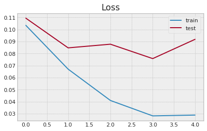

```python
plt.title('Loss')
plt.plot(history.history['loss'], label='train')
plt.plot(history.history['val_loss'], label='test')
plt.legend()
plt.show();
```

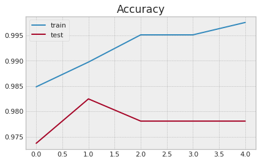

```python
plt.title('Accuracy')
plt.plot(history.history['accuracy'], label='train')
plt.plot(history.history['val_accuracy'], label='test')
plt.legend()
plt.show();
```

```python
predictions_lstm = model.predict(X_test)
label_mapping_lstm = np.argmax(Y_test, axis=-1)

print("Classification report: \n{}\n".format(
    classification_report(label_mapping_lstm, np.argmax(predictions_lstm, axis=-1))))
```

```
Classification report:
              precision    recall  f1-score   support

           0       0.99      1.00      0.99        67
           1       1.00      1.00      1.00        63
           2       1.00      1.00      1.00        62
           3       1.00      1.00      1.00        71
           4       1.00      1.00      1.00        67
           5       0.93      1.00      0.97        69
           6       1.00      1.00      1.00        69
           7       1.00      0.57      0.73        79
           8       1.00      1.00      1.00        72
           9       0.96      1.00      0.98        79
          10       0.98      1.00      0.99        83
          11       0.74      1.00      0.85        64
          12       1.00      1.00      1.00        59
          13       1.00      1.00      1.00        71

    accuracy                           0.97       975
   macro avg       0.97      0.97      0.96       975
weighted avg       0.97      0.97      0.96       975
```

```python
lst2_lstm=np.argmax(predictions_lstm, axis=-1)
lst3_lstm=[]
for i in label_mapping_lstm:
  lst3_lstm.append("lstm")
df_lstm=pd.DataFrame(list(zip(label_mapping_lstm, lst2_lstm,lst3_lstm)),
               columns =['Actual', 'Predicted','Model'])
```

# Compare model results

```python
df_final=df_lstm.append(df_NN)
```

```python
df_rest=pd.concat([lgbm_countVec_act_pred, lgbm_tfidf_act_pred, rfc_countVec_act_pred, rfc_tfidf_act_pred, xgb_countVec_act_pred, xgb_tfidf_act_pred])
```

## Accuracy Comparison

[figure not shown]

```python
# comparison

models = ['LGBM_count_vec','LGBM_tfidf','RF_count_vec','RF_tfidf','XGBoost__count_vec','XGBoost_tfidf','Neural Network','LSTM']
model_training_accuracy = [97,99,100,100,99,99,98,99.9]
model_validation_accuracy = [93,95,98,99,96,96,96,98.25]

performance = pd.DataFrame({
    'Model': models,
    'Training Accuracy': model_training_accuracy,
    'Validation Accuracy': model_validation_accuracy
})
performance[['Model','Training Accuracy','Validation Accuracy']].plot(x='Model',kind='bar',figsize=(20,5),title='Performance Comparison')
plt.xlabel("Critical Risk")
plt.xticks(rotation=50,ha='right')
plt.ylabel("Accuracy")
plt.show()
```

```python
from sklearn.metrics import recall_score,precision_score, f1_score

model_df=[lgbm_countVec_act_pred, lgbm_tfidf_act_pred, rfc_countVec_act_pred, rfc_tfidf_act_pred, xgb_countVec_act_pred, xgb_tfidf_act_pred,df_NN,df_lstm]
models = ['LGBM_count_vec','LGBM_tfidf','RF_count_vec','RF_tfidf','XGBoost__count_vec','XGBoost_tfidf','Neural Network','LSTM']
recall_list=[]
prec_list=[]
f1_list=[]
for i in range(0,len(model_df)):
  j=model_df[i]
  recall_list.append(recall_score(j['Actual'],j['Predicted'],average='micro'))
  prec_list.append(precision_score(j['Actual'],j['Predicted'],average='micro'))
  f1_list.append(f1_score(j['Actual'],j['Predicted'],average='micro'))
```

## Recall Comparison

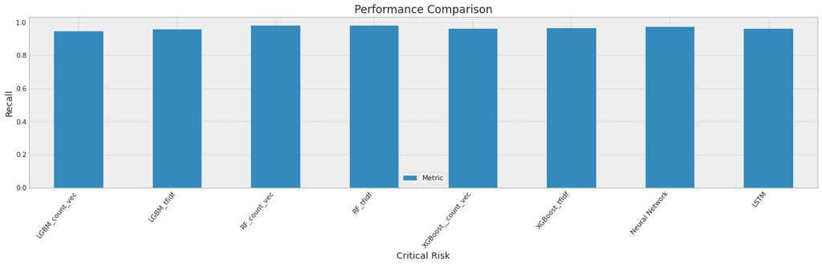

```python
models = ['LGBM_count_vec','LGBM_tfidf','RF_count_vec','RF_tfidf','XGBoost__count_vec','XGBoost_tfidf','Neural Network','LSTM']

model_metric= recall_list

performance = pd.DataFrame({
    'Model': models,
    'Metric': model_metric
})
performance[['Model','Metric']].plot(x='Model',kind='bar',figsize=(20,5),title='Performance Comparison')
plt.xlabel("Critical Risk")
plt.xticks(rotation=50,ha='right')
plt.ylabel("Recall")
plt.show()
```

## Precision Score comparison

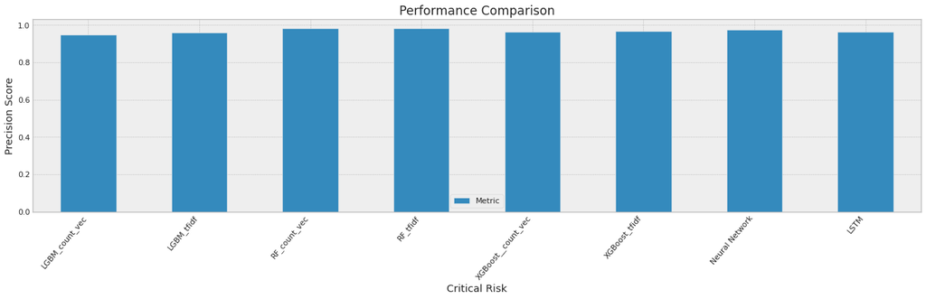

```python
models = ['LGBM_count_vec','LGBM_tfidf','RF_count_vec','RF_tfidf','XGBoost__count_vec','XGBoost_tfidf','Neural Network','LSTM']

model_metric= prec_list

performance = pd.DataFrame({
    'Model': models,
    'Metric': model_metric
})
performance[['Model','Metric']].plot(x='Model',kind='bar',figsize=(20,5),title='Performance Comparison')
plt.xlabel("Critical Risk")
plt.xticks(rotation=50,ha='right')
plt.ylabel("Precision Score")
plt.show()
```

## F1 Score Comparison

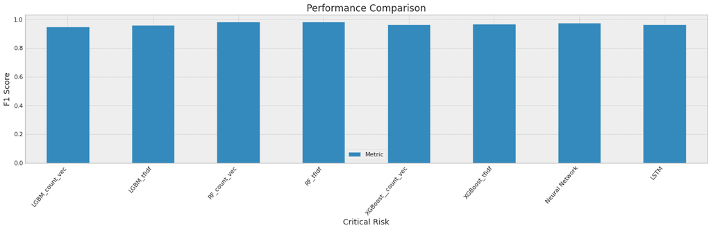

```python
models = ['LGBM_count_vec','LGBM_tfidf','RF_count_vec','RF_tfidf','XGBoost__count_vec','XGBoost_tfidf','Neural Network','LSTM']

model_metric= f1_list

performance = pd.DataFrame({
    'Model': models,
    'Metric': model_metric
})
performance[['Model','Metric']].plot(x='Model',kind='bar',figsize=(20,5),title='Performance Comparison')
plt.xlabel("Critical Risk")
plt.xticks(rotation=50,ha='right')
plt.ylabel("F1 Score")
plt.show()
```

```python
from sklearn import metrics

def conf_mat(y_test, y_pred,mod):
  index_cols=["Bees/Venomous Animals","Blocking and isolation of energies","Fall","Hazards during Electrical installations","Injuries/Cuts","Manual Tools",
  "NA","Others","Power lock","Pressed","Pressurized Systems/ Chemical Substances","Projections of fragments","Suspended Loads","Vehicles and Mobile Equipment"]

  preds_cols=["Predicted Bees/Venomous Animals","Predicted Blocking and isolation of energies","Predicted Fall","Predicted Hazards during Electrical installations",
  "Predicted Injuries/Cuts","Predicted Manual Tools","Predicted NA","Predicted Others","Predicted Power lock","Predicted Pressed","Predicted Pressurized Systems/ Chemical Substances",
  "Predicted Projections of fragments","Predicted Suspended Loads","Predicted Vehicles and Mobile Equipment"]
  model_name="Confusion Matrix for "+mod
  cm2=metrics.confusion_matrix(y_test, y_pred)
  df_cm2 = pd.DataFrame(cm2, index = [i for i in index_cols],
                    columns = [i for i in preds_cols])
  plt.figure(figsize = (10,10))
  #figure, axes = plt.figure(nrows=4, ncols=2, figsize=(20,20))
  plt.title(model_name)
  sns.heatmap(df_cm2, annot=True);
```